# ST661 R_PROJECT

Group: 12** - Jack Francis Hickey, Kaimo Zhang, Aveek Das, James Doherty Ferris

12/11/2020

## Introduction

**Objective:** This report will look at the road accident casualties between Males and Females, in Ireland for the years 2005 to 2018, the dataset is broken down into different cohorts (age group, road user type). Included in the dataset is the severity of the accident (injured or killed). There is no spatial data represented in the dataset so accident location cannot be deemed to be a contributing factor.

What we set out to do was determine if there were any differences between the genders, age groups or different road user types. We referred to outside data, specifically the RSA and CSO for figures on drivers licenses in issue in 2018 and the population numbers to aid our data analysis and draw conclusions. We also attempt to predict these trends into the future.

Some of the generally held views are that young men get killed a lot on the roads. Another would be that women are involved in a lot of non-fatal accidents. We have produced several charts plotting the relationship between road user type, genders and age groups and we have conducted data analysis on the data set to try and answer our initial questions and identify trends in casualty rates of different cohorts. We’ll produce graphical explanations for these trends and ultimately through predictive analysis, determine what directions these trends seem to be heading towards in the future.

**Responsibilities:**

- Data Cleaning - James Ferris
- Age Analysis - Jack Hickey
- Road User Type Analysis - Aveek Das
- Gender Analysis - Kaimo Zhang

Although we divided the tasks and shared responsibilities, it was a collaboration of efforts and input was made into each group by all four of us. Final analysis and conclusions were a joint effort.

## Cleaning

```r
# Understanding the Road User Type based on Age Group and Gender
library(pxR)
```

```r
library(ggplot2)
library(tidyverse)
df = as.data.frame(read.px("ROA16.px"))
names(df)<-c("Statistic","Year","Road.User.Type","Sex","Age.Group","value")
head(df)
```

```
##                                    Statistic Year Road.User.Type  Sex Age.Group
## 1                 Killed Casualties (Number) 2005 All road users Male  All ages
## 2               Injured Cassualties (Number) 2005 All road users Male  All ages
## 3 All Killed and Injured Casualties (Number) 2005 All road users Male  All ages
## 4                 Killed Casualties (Number) 2006 All road users Male  All ages
## 5               Injured Cassualties (Number) 2006 All road users Male  All ages
## 6 All Killed and Injured Casualties (Number) 2006 All road users Male  All ages
##   value
## 1   286
## 2  4688
## 3  4974
## 4   262
## 5  4466
## 6  4728
```

```r
#check for na's
sapply(df, function(x) which(is.na(x)))
```

```
## $Statistic
## integer(0)
##
## $Year
## integer(0)
##
## $Road.User.Type
## integer(0)
##
## $Sex
## integer(0)
##
## $Age.Group
## integer(0)
##
## $value
## integer(0)
```

```r
# Filter all the redundant data

df <- df %>%
  filter(df$Statistic != "All Killed and Injured Casualties (Number)"&df$Road.User.Type != "All road users"&df$Road.User.Type != "All Car users"&df$Age.Group != 'All ages')

sum(df$value) #112279
```

```
## [1] 112279
```

## Visual analysis

### Age analysis

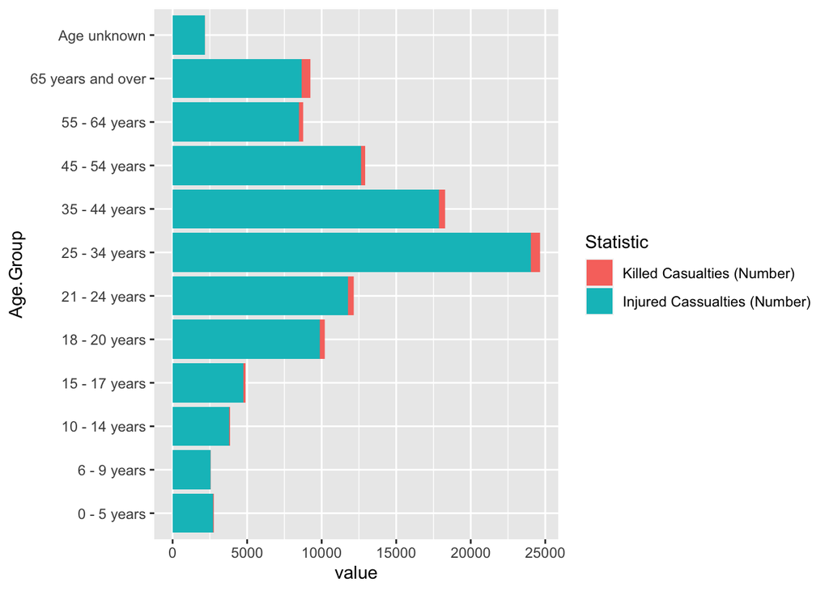

```
##   age_groups     avgs
## 1    15 - 17 14.49702
## 2    18 - 20 30.34524
## 3    21 - 24 36.12202
## 4    25 - 34 73.33333
## 5    35 - 44 54.38690
## 6    45 - 54 38.38690
## 7    55 - 64 26.02083
## 8        65+ 27.46429
```

From the graph above first of all we can see that it is far more common for a casualty on the road to be just an injury rather than resulting in someone being killed. We then notice that the graph shows clearly a much higher rate of casualty for the two age categories 25-34 and 35-44 years. Upon first observation we feel like this would be mainly due to the fact that there are simply more Road users in these age categories after all there is a smaller age gap between the younger cohorts than the older ones, meaning statistically it would make sense for more accidents to occur in these cohorts.

Here we are going to look deeper into the younger casualties on Irish roads and determine if they in fact are the more dangrous drivers as their insurance companies lead them to believe.

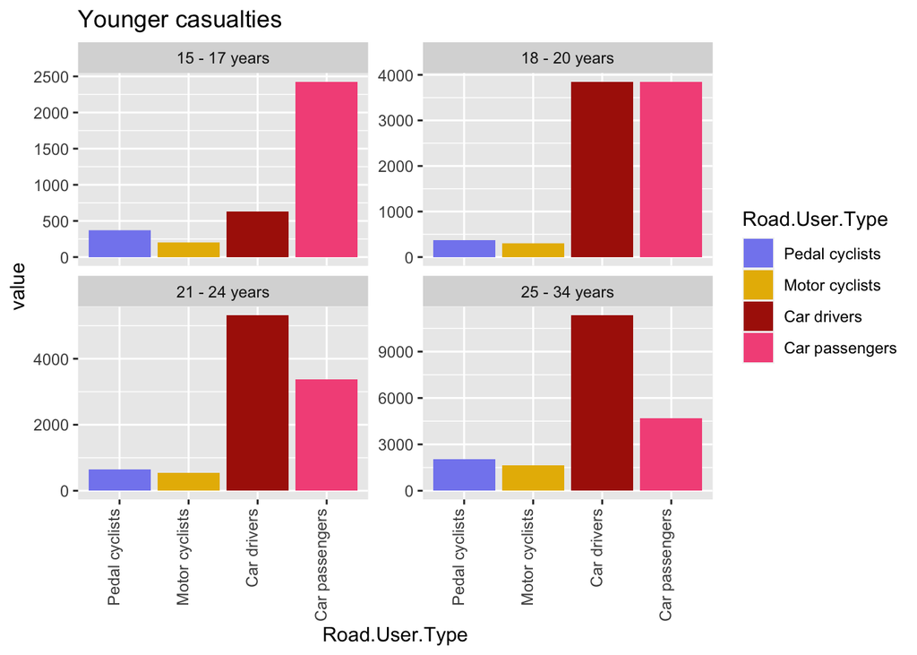

So we can determine that the main cause of casualties among the younger road users is from car accidents. Notably the youngest group in the graph above being a car passenger is the biggest cause of casualty for the 15-17 year olds. Upon inspection of the values on the y-axis of these graphs, the car drivers in the 25-34 year olds are by far the highest producer of casualties (~11,000). There is an even match-up comparing car drivers and passengers for the 18-20 year olds, which fits in with the idea that there is bound to be a large amount of 18-20 year olds being passengers in cars with unexperienced drivers (other 18-20 year olds).

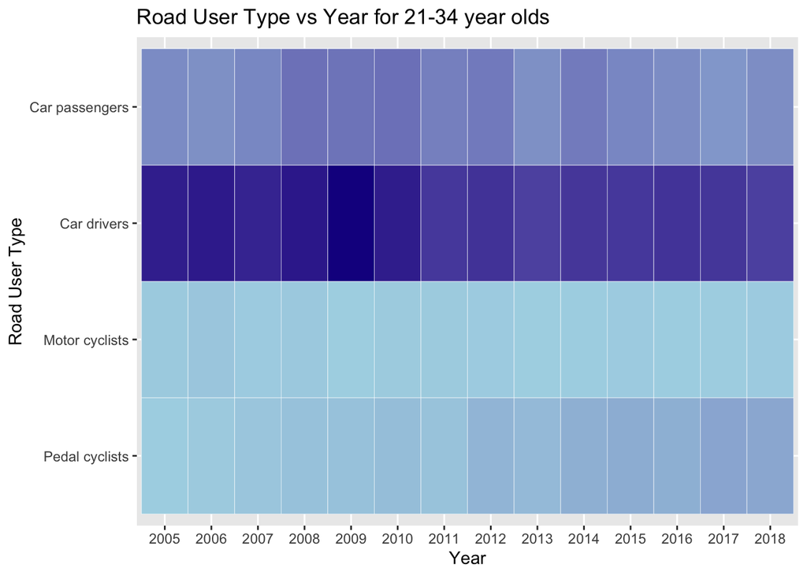

Above the heatmap for 21-34 year olds grouped together gives shows the domination of the Car drivers category in terms of casualties, the darkest colour in 2009 allows us to see that this was a particularly bad year casualty-wise. On a lighter note the values lower now than they were at this peak in 2009, as indicated by the lighter shades of blue. Interestingly pedal cyclists seem to be getting involved in more accidents as their colour ramp gets darker as we move along the graph from 2005 to 2018.

```r
sub7<- df[(df$Road.User.Type=='Car drivers')  & (df$Age.Group == '18 - 20 years'|df$Age.Group == '21 - 24 years'| df$Age.Group == '25 - 34 years'),]

f<-lm(value~Statistic+Sex+Age.Group, data=sub7)
summary(f)
```

```
##
## Call:
## lm(formula = value ~ Statistic + Sex + Age.Group, data = sub7)
##
## Residuals:
##     Min      1Q  Median      3Q     Max
## -135.14  -70.58   19.19   44.81  225.76
##
## Coefficients:
##                                       Estimate Std. Error t value Pr(>|t|)
## (Intercept)                             -36.82      12.38  -2.973   0.0034 **
## StatisticInjured Cassualties (Number)   236.81      11.08  21.379   <2e-16 ***
## SexFemale                               -20.86      11.08  -1.883   0.0615 .
## Age.Group21 - 24 years                   27.13      13.57   1.999   0.0472 *
## Age.Group25 - 34 years                  136.25      13.57  10.043   <2e-16 ***
## ---
## Signif. codes:  0 '***' 0.001 '**' 0.01 '*' 0.05 '.' 0.1 ' ' 1
##
## Residual standard error: 71.79 on 163 degrees of freedom
## Multiple R-squared:  0.7787, Adjusted R-squared:  0.7733
## F-statistic: 143.4 on 4 and 163 DF,  p-value: < 2.2e-16
```

In the linear model above we see the SexFemale column is insignificant at a confidence level.The model shows significance for the other values we put in to it, before interpretting these we much remove the Sex value due to its insignificance.

```r
f<-lm(value~Statistic+Age.Group, data=sub7)
summary(f)
```

```
##
## Call:
## lm(formula = value ~ Statistic + Age.Group, data = sub7)
##
## Residuals:
##     Min      1Q  Median      3Q     Max
## -145.56  -70.18   20.62   49.24  236.19
##
## Coefficients:
##                                       Estimate Std. Error t value Pr(>|t|)
## (Intercept)                             -47.24      11.16  -4.232 3.84e-05 ***
## StatisticInjured Cassualties (Number)   236.81      11.16  21.215  < 2e-16 ***
## Age.Group21 - 24 years                   27.13      13.67   1.984   0.0489 *
## Age.Group25 - 34 years                  136.25      13.67   9.966  < 2e-16 ***
## ---
## Signif. codes:  0 '***' 0.001 '**' 0.01 '*' 0.05 '.' 0.1 ' ' 1
##
## Residual standard error: 72.34 on 164 degrees of freedom
## Multiple R-squared:  0.7739, Adjusted R-squared:  0.7698
## F-statistic: 187.1 on 3 and 164 DF,  p-value: < 2.2e-16
```

Now this second linear model without the gender input shows us predicted values in the Estimate comlumn for b0,b1,b2,b3. The interesting values of this linesr model are the age group categories and the model says that for for a one unit(person) rise in people aged 25-34 we expect an increase in casualties by 136.25, where as only a rise of 27.13 for an increase of one unit of people aged 21-24. This is interesting as it backs up the original claim that the most dangerous drivers are belonging to the 25-34 year old cohort.

```r
RSA_data <- read_csv("RSA_data.csv")
rsatot_allages<- RSA_data[RSA_data$Year=="2018" & RSA_data$`Age Group`=="All ages",]
rsatot_young<- RSA_data[RSA_data$Year=="2018" & (RSA_data$`Age Group`=="17 - 20 years" | RSA_data$`Age Group`=="21 - 24 years"),]



sum_all<-sum(rsatot_allages$VALUE)
sum_young<-sum(rsatot_young$VALUE)

young_total<-sum(c(w$value,w1$value,w2$value))
all_total<-sum(c(w$value,w1$value,w2$value,w3$value,w4$value,w5$value,w6$value,w7$value))

all_total/sum_all
```

```
## [1] 0.03473696
```

```r
young_total/sum_young
```

```
## [1] 0.1166617
```

```r
rsatot_older<- RSA_data[RSA_data$Year=="2018" & RSA_data$`Age Group`=="30 - 39 years",]
sum_older<-sum(rsatot_older$VALUE)

older_total<-sum(w3$value) #here w3 is the 25-34 year olds
older_total/sum_older
```

```
## [1] 0.0396195
```

The calculations above show that according to the RSA (https://data.cso.ie/), in 2018 there was 233,187 drivers aged 17-24 with Irish licenses (full or provisional) on our roads. Using values from the Casualties data, calculated that the proportion of these drivers to be recorded killed or injured was = ~0.1166, hence about 1 in 9 drivers 17-24 were classified as injured or killed, thankfully of this number the big majority was injured as seen earlier (this statistic is not taking into account those who were unlucky enough to be a casualty twice in 2018). Now when we do this calculation for the whole population we get the much smaller proportion of ~0.0347 or about 1 in 29 drivers of the total driving population.

So when we compare the younger drivers to the overall population they are about 3 times more likely to become a casualty from driving a car.

<<older_total<-sum(w3$value) #here w3 is the 25-34 year olds>> <> This code above was just done in order to slightly clarify the fact that the younger drivers present more of a danger on the roads, the data doesnt match up, it is dividing the casualties for 24-35 year olds by the total irish 30-39 year olds, which gives a proportion of ~0.0396. Since the RSA data and the casualty data didnt quite match up this is the closest we can do.

### Road User Type Analysis

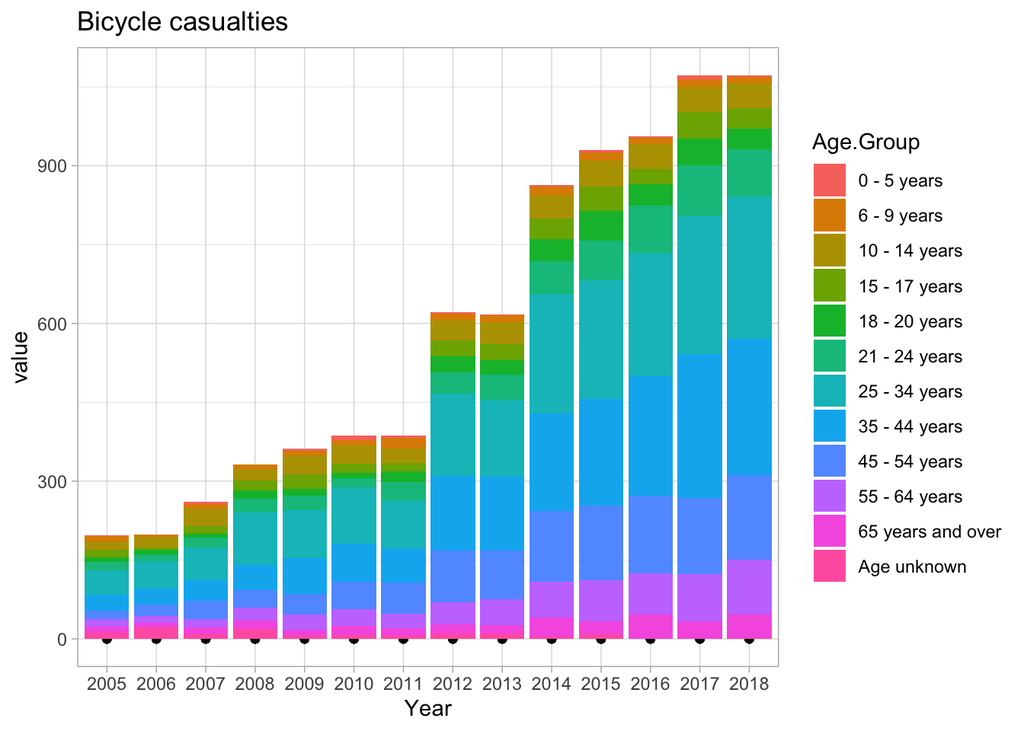

What we are seeing in this chart is an increasing number of cyclists across all age groups. Unfortunately, this leads to an increasing volume of accidents that involve cyclists, and their consequent inclusion in the road accident statistics. The 25-34 and 35-44 age groups are making up the largest cohort in driving up these numbers.

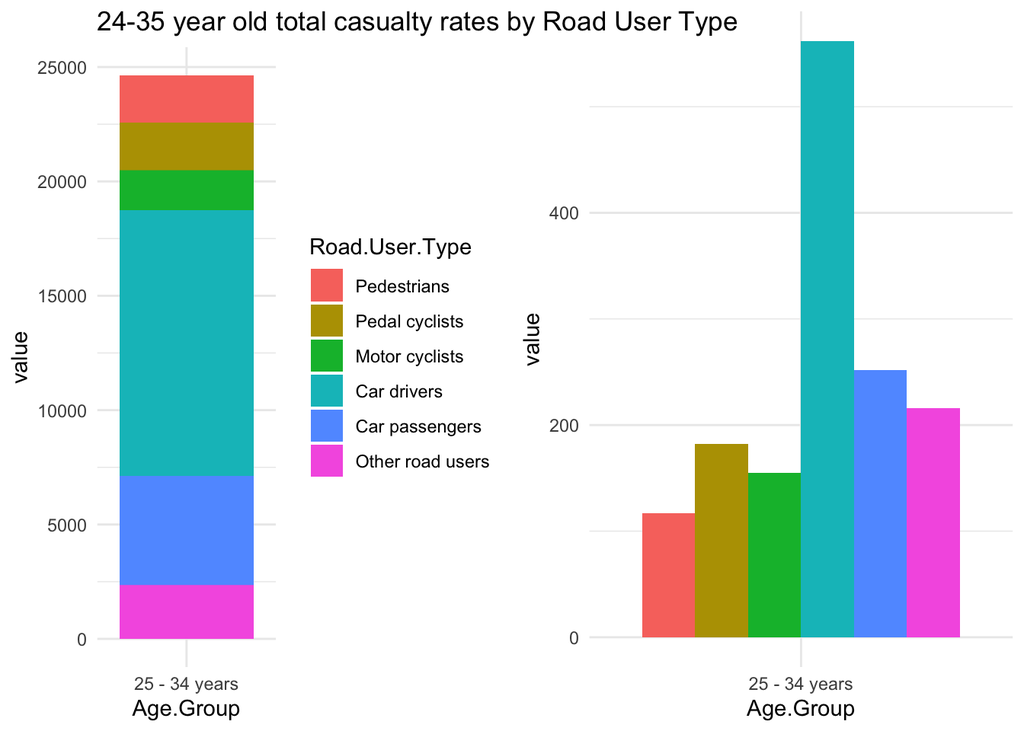

In the above we can see that the most affected road users age group is the one between 24 to 35 years. Upon further analysis into this age group, we see that the car drivers in this age group had major casualties and the motor cyclists had the least. This can also be supported by the fact that the number of car drivers are much higher as compared to the motor cyclists on an average.

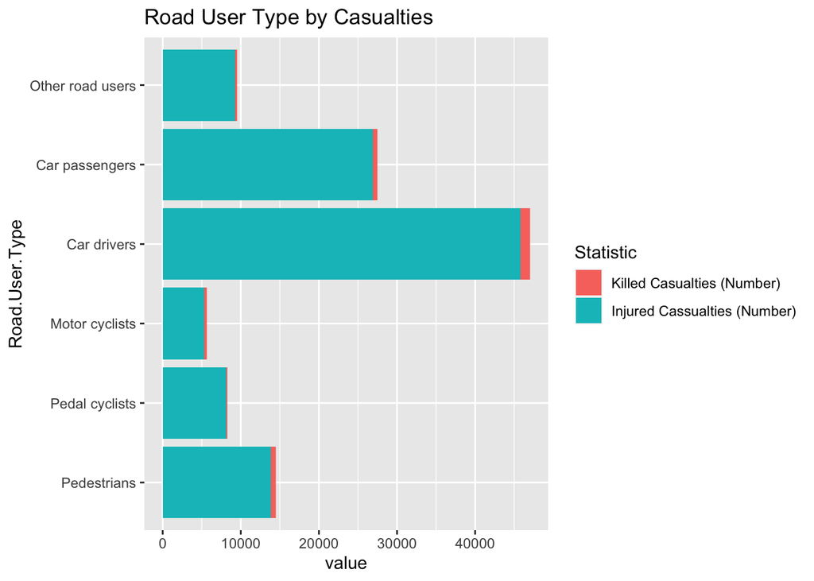

From the above, we can conclude that the Car Drivers having the highest Casualties Count.

#### Proportion of Male and Female Car Driving Death Casualties Trend over 14 years.

```
##  [1] 0.02 0.02 0.02 0.02 0.02 0.01 0.02 0.02 0.01 0.01 0.01 0.01 0.01 0.01
```

```
##  [1] 0.05 0.05 0.05 0.03 0.03 0.03 0.03 0.02 0.04 0.03 0.03 0.04 0.02 0.02
```

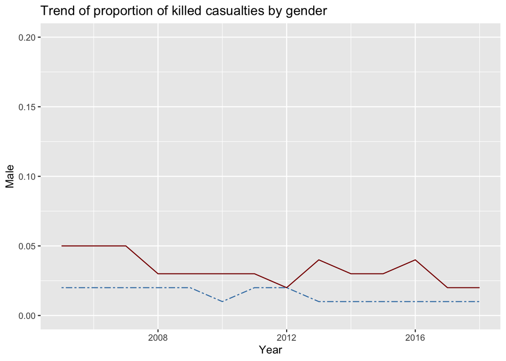

As we can see from the above line graph, there is a downward trend in the proportion of the killed casualties in both male and female. In 2005, about 5% of the total casualties for males resulted in deaths and 2% for females. This has gradually decreased over the years and now its about 2% for males and 1% for females.

#### Categorical Count of Age Group Wise Casualties for 14 years.

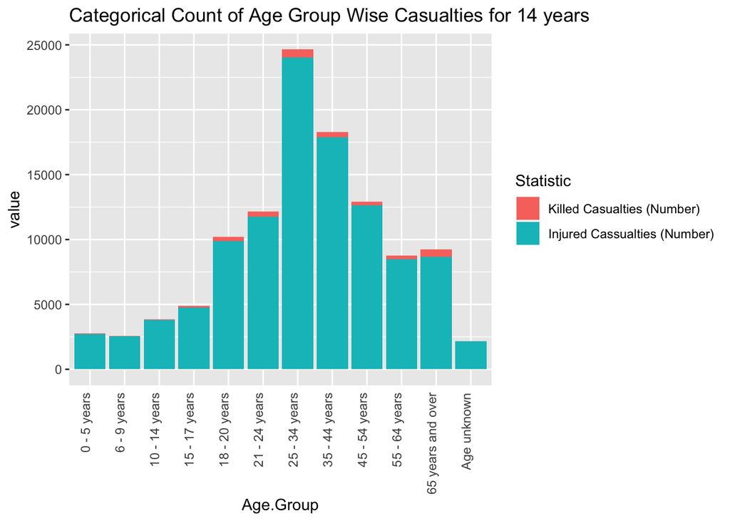

The age group containing 25-34 years has the highest number of casualties.

From the above we can conclude that the Road User Type of Pedal Cyclist has an increasing trend of casualties over the years. However, the proportions of fatalities is minimum.

### Gender Analysis

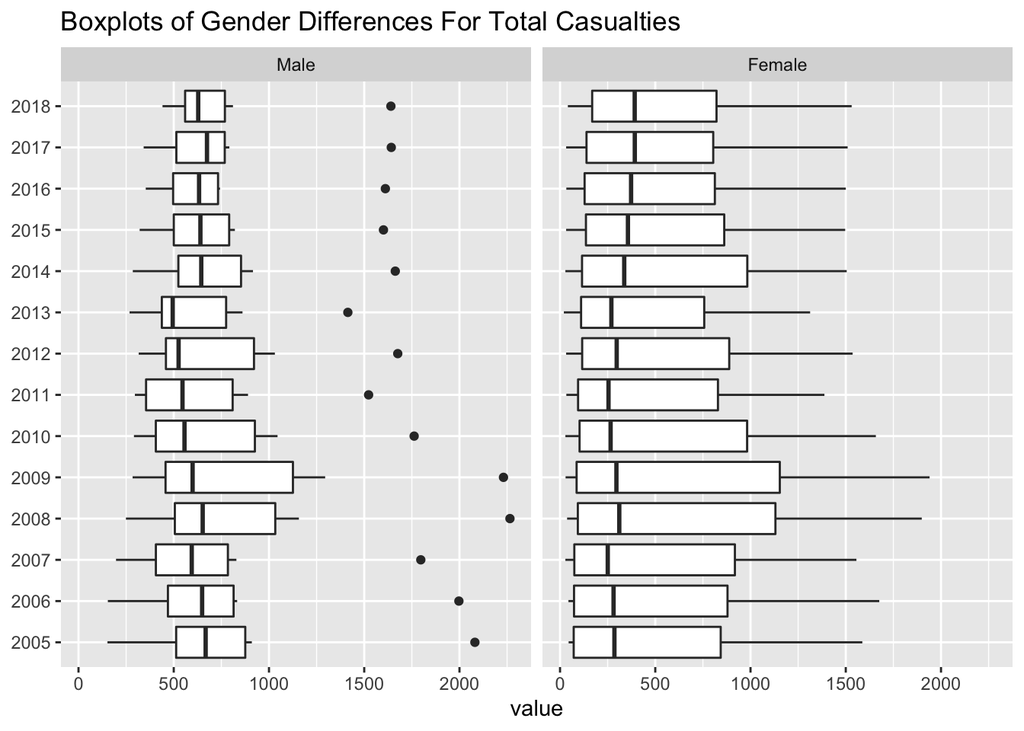

From the boxplots above firstly we notice that all the male boxplots possess an outlier for each year between the value range of ~1500 to ~2250. Secondly it is noteable that the female IQR is of range far wider than the males. For the males the two outliers for 2008 and 2009 are particularly high values for casualty, we saw earlier that this was a particularly high casualty year for young car drivers so this will be investigated.

In order to determine what cohorts are causing these values for Males and Females we break them down further into Road user types.

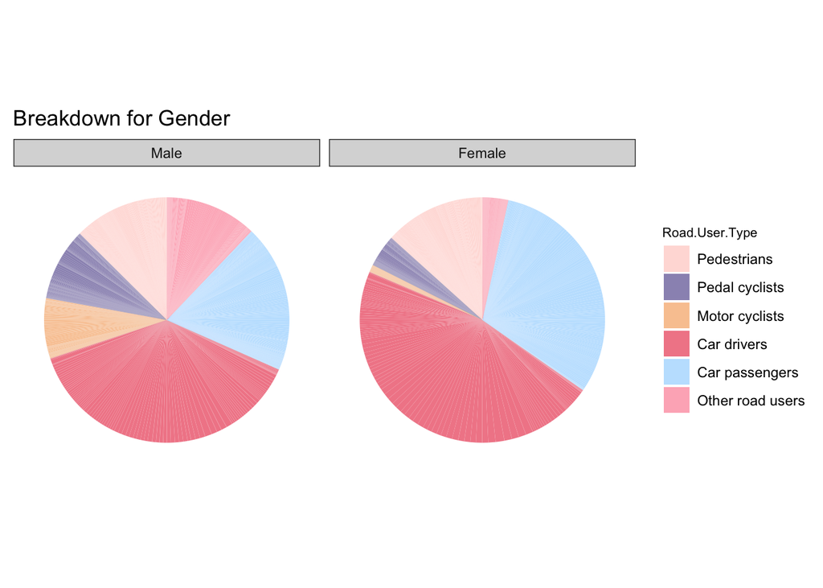

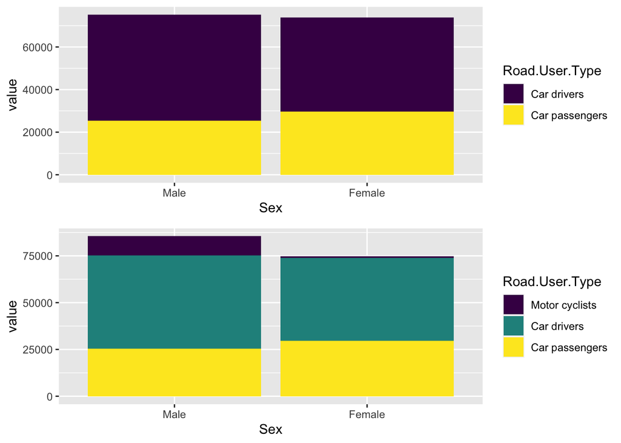

So when we break things down between gender, from this data it seems that there is no major difference between Males and Females for casualties caused by Car-use Males slightly edge the females in the first graph due to Males having more casualties from driving cars, but there are more Female car passengers injured or killed by quite a margin actually that almost caused the Females to catch up.

In the second graph when we just add the Motor cyclists on top of our two gender portions we see a big change in total casualty values now, almost 12,000 more casualties were present in the dataset for males compared to females when we include those who were hurt from a motorbike. This is in line with the observation that simply more males use motorcycles than females.

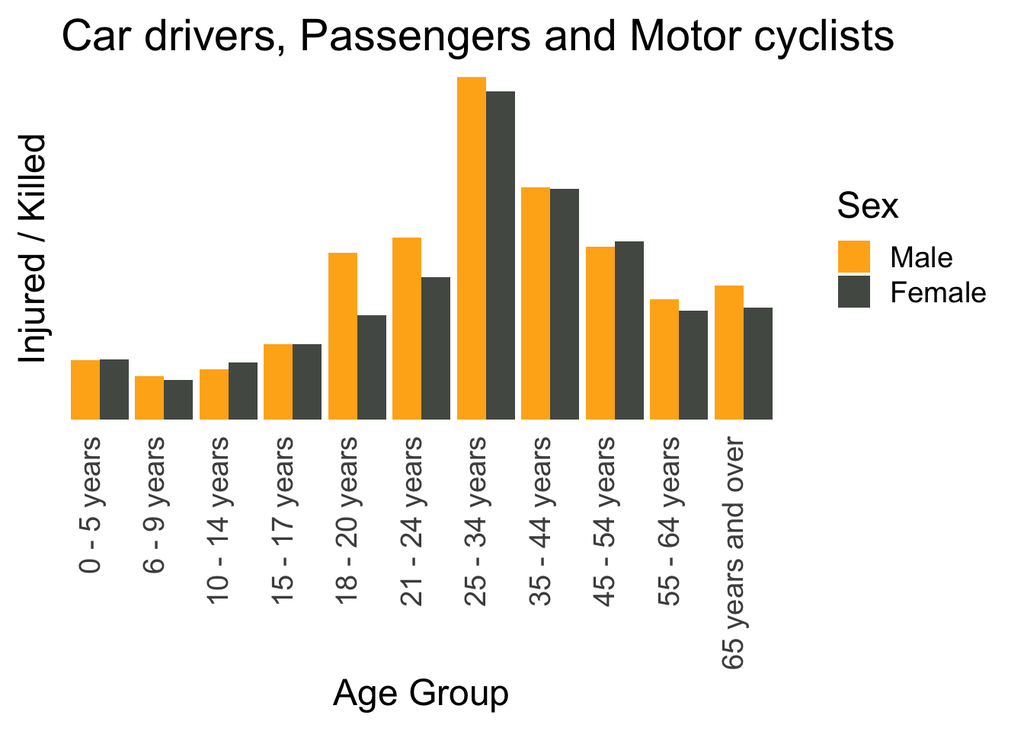

So finally we look at the age difference between the two genders for these three ‘dangerous’ categories. Interestingly the main disparaties comes from the 18-20 and 21-24 year olds where the Males values are noticably higher than females. Indeed this fits the general consensus that young male road users are more likely to get hurt on the roads. From this graph although at first it seems tight to differentiate between the genders, but the 18-20 and 21-24 year olds drive the male numbers above the females and in fact there are only two age categories where Females clearly have greater casualty values (10-14 and 45-54 years).

## Conclusion

Upon first inspection of the data it was strinkingly evident that the ‘worst’ age category for casualties on Irish roads was the 25-34 year olds, but upon further analysis this seemed not to fully be the case, yes they are the cohort that produces the largest value, but as we saw from the analysis using the RSA data, in fact the younger drivers (17-24) were nearly three times more likely to become a casualty due to driving a car. Some things we discovered just simply backed up intuition, like there was far more 15-17 year olds involved in accidents as car passengers as for any other form of road use. Due to the data not matching up from the RSA and the casualty rates we couldnt not fully judge the difference between the 17-24 and the 24-35 year olds, although the analysis that was done did show that the younger cohorts group was still ~3 times larger than the averaged two groups.